# 39_semi-log_get_base

## 39_semi-log_get_base

#### Question

1. An exponential growth curve, $y=B^x$ with base $B>1$, is graphed below using a [semi-log plot](https://en.wikipedia.org/wiki/Semi-log_plot).

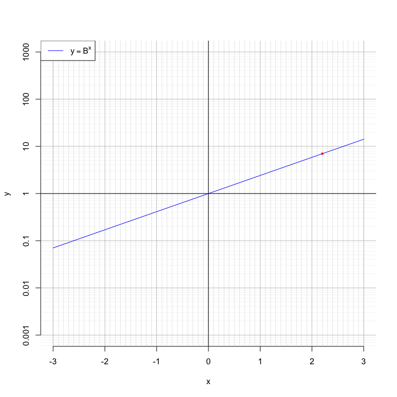

   Based on the red point, estimate the base $B$.

#### Question

2. An exponential growth curve, $y=B^x$ with base $B>1$, is graphed below using a [semi-log plot](https://en.wikipedia.org/wiki/Semi-log_plot).

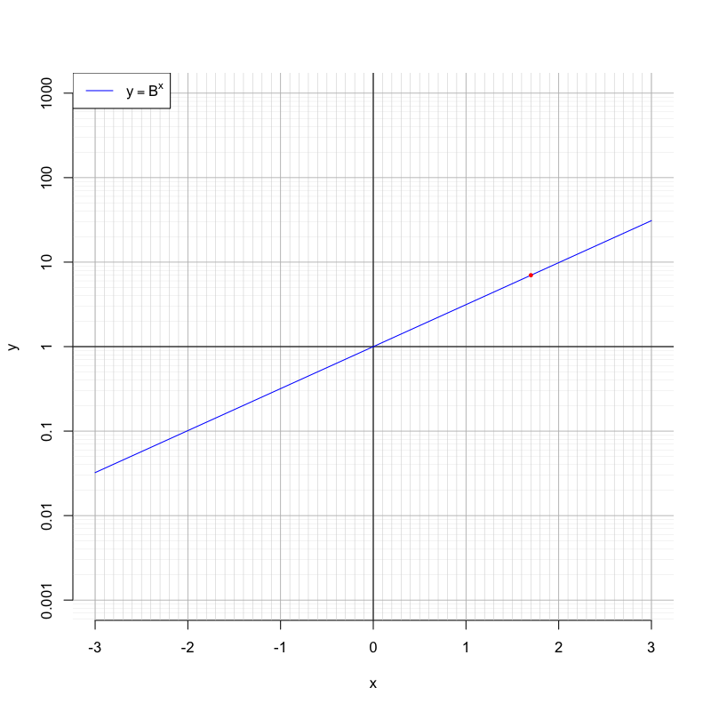

   Based on the red point, estimate the base $B$.

#### Question

3. An exponential growth curve, $y=B^x$ with base $B>1$, is graphed below using a [semi-log plot](https://en.wikipedia.org/wiki/Semi-log_plot).

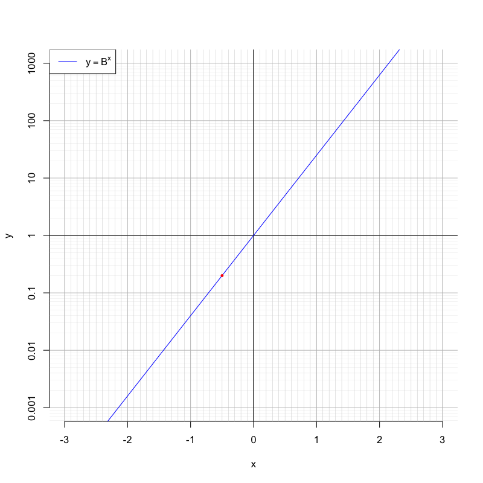

   Based on the red point, estimate the base $B$.

#### Question

4. An exponential growth curve, $y=B^x$ with base $B>1$, is graphed below using a [semi-log plot](https://en.wikipedia.org/wiki/Semi-log_plot).

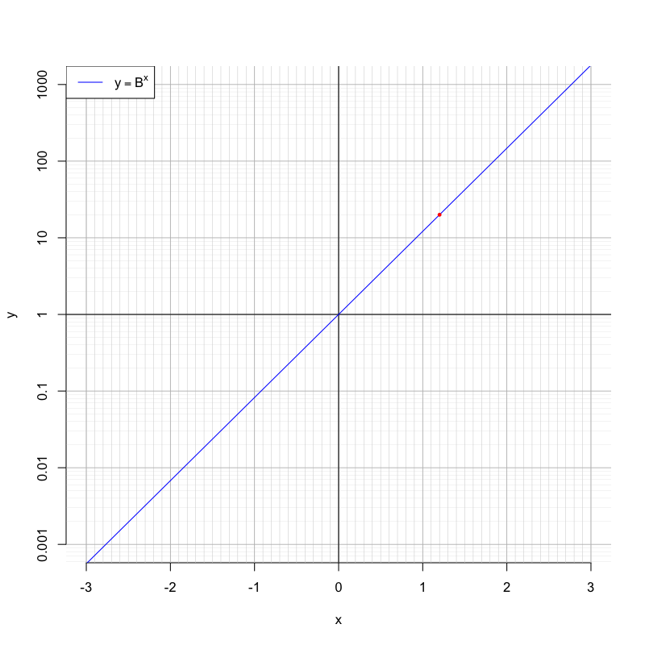

   Based on the red point, estimate the base $B$.

#### Question

5. An exponential growth curve, $y=B^x$ with base $B>1$, is graphed below using a [semi-log plot](https://en.wikipedia.org/wiki/Semi-log_plot).

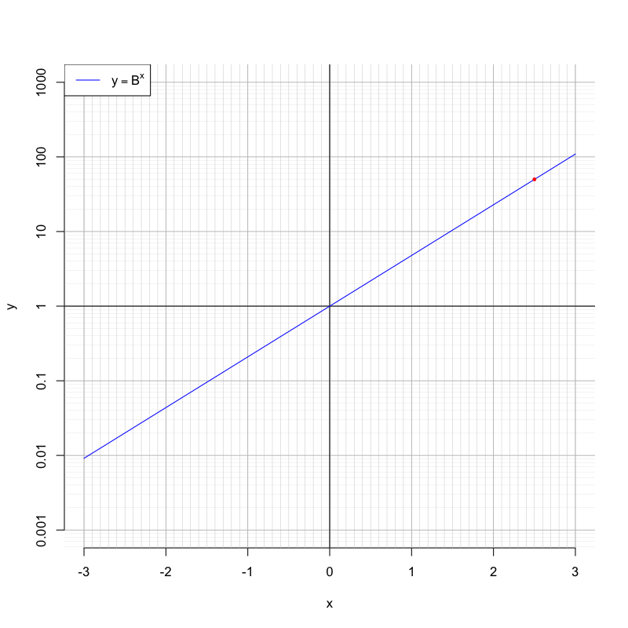

   Based on the red point, estimate the base $B$.

#### Question

6. An exponential growth curve, $y=B^x$ with base $B>1$, is graphed below using a [semi-log plot](https://en.wikipedia.org/wiki/Semi-log_plot).

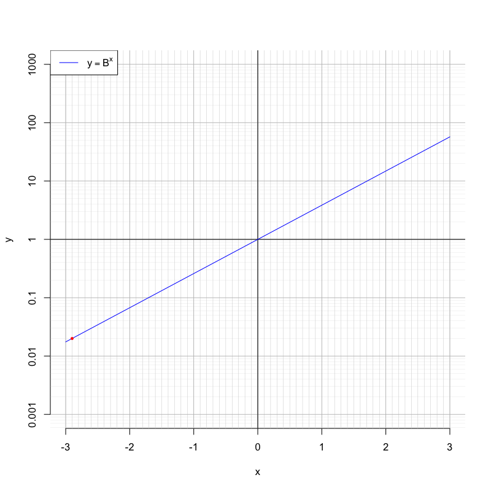

   Based on the red point, estimate the base $B$.

#### Question

7. An exponential growth curve, $y=B^x$ with base $B>1$, is graphed below using a [semi-log plot](https://en.wikipedia.org/wiki/Semi-log_plot).

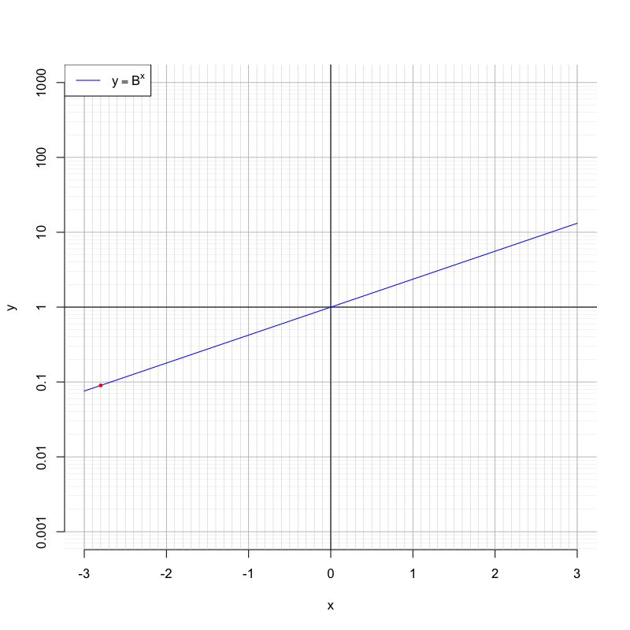

   Based on the red point, estimate the base $B$.

#### Question

8. An exponential growth curve, $y=B^x$ with base $B>1$, is graphed below using a [semi-log plot](https://en.wikipedia.org/wiki/Semi-log_plot).

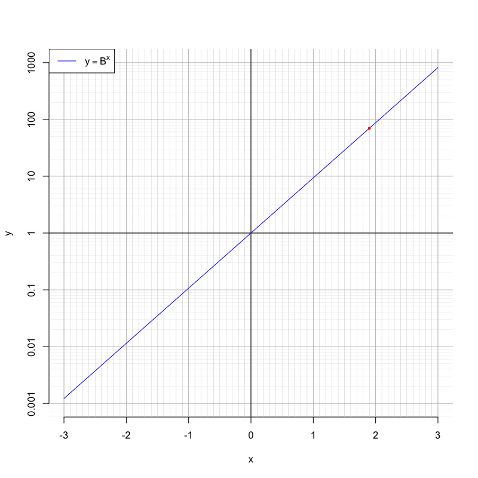

   Based on the red point, estimate the base $B$.